# Jar Jar Binks and Gender

```r
knitr::opts_chunk$set(echo = TRUE, message = FALSE, warning = FALSE, error = TRUE)
```

# Context

FiveThirtyEight, a data focused institution, did a survey of hundreds of people in their opinions about Star Wars related things. Additionally, it includes demographic information. This prompted me to wonder if there is an association between liking Jar Jar Binks and gender.

The code below will load in the data and wrangle it accordingly to allow a basic logistic regression where gender is coded as Male:1 and Female:0.

```r
library(tidyverse)

sw <- read_csv('https://query.data.world/s/ltpeqopncwivu3oar56jo7iyf5m3x2', locale=locale(encoding="latin1"))

binks <- bind_cols(
(sw |> select(1,27) ),
(sw |> select(Gender))
)

binks1 <- binks |>
  rename(id = RespondentID, binks = ...2, sex = Gender) |>
  filter(binks %in% c("Very favorably", "Very unfavorably", "Somewhat favorably", "Somewhat unfavorably", "Neither favorably nor unfavorably (neutral)")) |>
  mutate(binks=recode(binks,
    "Very favorably" = '2',
    "Somewhat favorably" = '1',
    "Neither favorably nor unfavorably (neutral)" = '0',
    "Somewhat unfavorably" = '-1',
    "Very unfavorably" = '-2'),
    sex = recode(sex, "Male" = "1", "Female" = "0"),
    binks = binks |> as.numeric(),
    sex = sex |> as.numeric(),
    )
```

# Hypotheses

The null hypothesis is that there is no relationship between the favorabilitiy of Jar Jar Binks and the log of the odds that the gender of the person is male. In other words, the favorability of Jar Jar Binks is not useful in predicting the probability that the gender of the observed survey taker is male. If $β_1≠0$, then there is information in the favorability score that can be utilized to predict the probability that the gender of the survey taker is male, i.e., the logistic regression is meaningful.

$$H_0: \beta_1 = 0 \\
H_a: \beta_1 \neq 0$$
# Checking requirements

Deviance Goodness of Fit Test Since there are replicated values of each Jar Jar favorability rating, then the model I will use to test the goodness of fit is the **deviance goodness of fit test** which will test the hypotheses.

**Deviance Goodness-of-fit Test Result**

```r
YourGlmName <- glm(sex > 0 ~ binks, data = binks1, family=binomial)

# Deviance Goodness-of-fit Test (Less Common)
pchisq(summary(YourGlmName)$deviance[1],
       summary(YourGlmName)$df[2],
       lower.tail=FALSE) |> pander::pander()
```

*8.252e-10* This indicates that the data is probably not a good fit.

# Graph

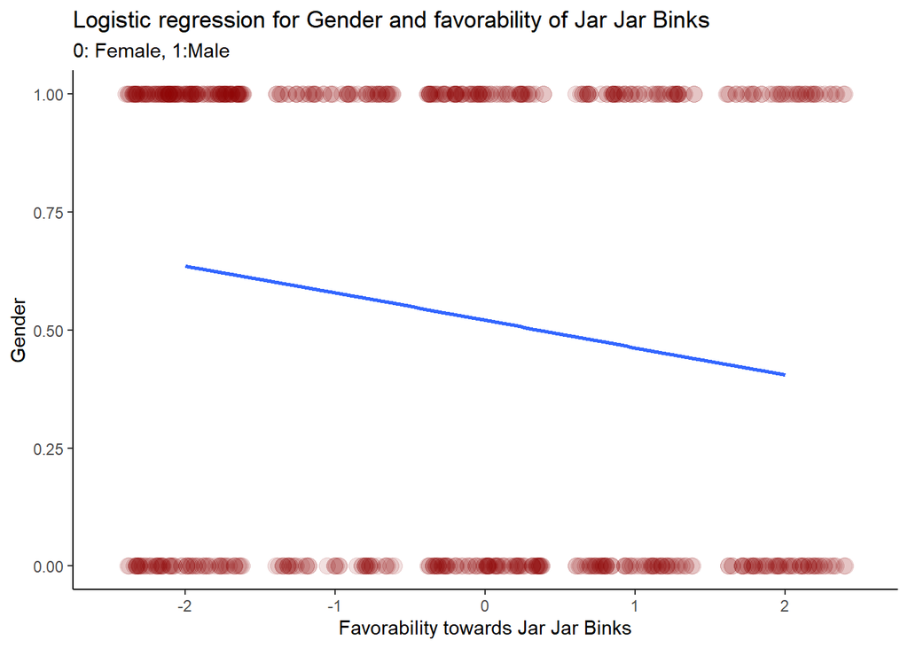

```r
ggplot(data = binks1, aes(x = binks, y = sex)) +
  geom_jitter(size = 4,
              alpha = .12,
              height = .00,
              width = .40,
              color = "darkred") +
  geom_smooth(method="glm",
              method.args = list(family="binomial"),
              se = FALSE) +
  theme_classic() +
  coord_cartesian(xlim = c(-2.5, 2.5)) +
  labs(title = "Logistic regression for Gender and favorability of Jar Jar Binks",
       subtitle = "0: Female, 1:Male",
       x = "Favorability towards Jar Jar Binks",
       y = "Gender")
```

# Prediction

Below is the code that creates predictions for the favorability levels, -2 and 2.

predict(YourGlmName, newdata = data.frame(binks = -2), type = “response”) |> (function(x) round((x)*100, 2))()

predict(YourGlmName, newdata = data.frame(binks = 2), type = “response”)|> (function(x) round((x)*100, 2))()

```r
predict(YourGlmName, newdata = data.frame(binks = -2), type = "response") |>
  (function(x) round((x)*100, 2))()
```

```
##    1
## 63.5
```

```r
predict(YourGlmName, newdata = data.frame(binks = 2), type = "response")|>
  (function(x) round((x)*100, 2))()
```

```
##    1
## 40.5
```

# Analyzing the Test

```r
YourGlmName <- glm(sex > 0 ~ binks, data = binks1, family = binomial)

summary(YourGlmName) |> pander::pander()
```

|  | Estimate | Std. Error | z value | Pr(>\|z\|) |
| --- | --- | --- | --- | --- |
| **(Intercept)** | 0.08461 | 0.07776 | 1.088 | 0.2766 |
| **binks** | -0.2346 | 0.05411 | -4.336 | 1.45e-05 |

(Dispersion parameter for binomial family taken to be 1 )

| Null deviance: | 963.1 on 696 degrees of freedom |
| --- | --- |
| Residual deviance: | 943.8 on 695 degrees of freedom |

This means that the odds of success increase by the factor of $e^{\beta1}$ or or for every one unit increase in $x_i$.

```r
(coef(YourGlmName)[2] |> exp() )
```

```
##    binks
## 0.790874
```

# Conclusion

From the p-value of this test, the trend is significant.

This means that we have enough evidence to reject the null hypothesis that there is no relationship between the favorabilitiy of Jar Jar Binks and the log of the odds that the gender of the person is male. In other words, we can reject the idea that the favorability of Jar Jar Binks is not useful in predicting the probability that the gender of the observed survey taker is male.